# Mini Project 2:-Consumer Complaint Resolution Analysis Using Python

**scenario**

Product review is the most basic function/factor in resolving customer issues and increasing the sales growth of any product. We can understand their mindset toward our service without asking each customer. When consumers are unhappy with some aspect of a business, they reach out to customer service and might raise a complaint. Companies try their best to resolve the complaints that they receive. However, it might not always be possible to appease every customer. So Here, we will analyze data, and with the help of different algorithms, we are finding the best classification of customer category so that we can predict our test data.

**Objective**

Use Python libraries such as Pandas for data operations, Seaborn and Matplotlib for data visualization and EDA tasks, Sklearn for model building and performance visualization, and based on the best model, make a prediction for the test file and save the output. The main objective is to predict whether our customer is disputed or not with the help of given data.

**Dataset Discription**

Customers faced some issues and tried to report their problems to customer care.

Dispute: This is our target variable based on train data; we have two groups, one with a dispute with the bank and another don’t have any issue with the bank.

Date received: The day complaint was received.

Product: different products offered by the bank (credit cards, debit cards, different types of transaction methods, accounts, locker services, and money-related)

Sub-product: loan, insurance, other mortgage options

Issue: Complaint of customers

Company public response: Company’s response to consumer complaint

Company: Company name

State: State where the customer lives (different state of USA)

ZIP code: Where the customer lives

Submitted via: Register complaints via different platforms (online web, phone, referral, fax, post mail)

Date sent to company: The day complaint was registered

Timely response?: Yes/no

Consumer disputed?: yes/no (target variable)

Complaint ID: unique to each consumer

**Tasks to be performed:**

• Read the Data from the Given excel file.

• Check the data type for both data (test file and train file)

• Do missing value analysis and drop columns where more than 25% of data are missing

• Extracting Day, Month, and Year from Date Received Column and create new fields for a month, year, and day

• Calculate the Number of Days the Complaint was with the Company and create a new field as “Days held”

• Drop "Date Received","Date Sent to Company","ZIP Code", "Complaint ID" fields

• Imputing Null value in “State” by Mode

• with the help of the days we calculated above, create a new field 'Week_Received' where we calculate the week based on the day of receiving.

• store data of disputed people into the “disputed_cons” variable for future tasks

• Plot bar graph of the total no of disputes of consumers with the help of seaborn

• Plot bar graph of the total no of disputes products-wise with the help of seaborn

• Plot bar graph of the total no of disputes with Top Issues by Highest Disputes, with the help of seaborn

• Plot bar graph of the total no of disputes by State with Maximum Disputes

• Plot bar graph of the total no of disputes Submitted Via different source

• Plot bar graph of the total no of disputes where the Company's Response to the Complaints

• Plot bar graph of the total no of disputes where the Company's Response Leads to Disputes

• Plot bar graph of the total no of disputes. Whether there are Disputes Instead of Timely Response

• Plot bar graph of the total no of disputes over Year Wise Complaints

• Plot bar graph of the total no of disputes over Year Wise Disputes

• Plot bar graph of Top Companies with Highest Complaints

• Converte all negative days held to zero (it is the time taken by the authority that can't be negative)

• Drop Unnecessary Columns for the Model Building like:'Company', 'State', 'Year_Received', 'Days_held'

• Change Consumer Disputed Column to 0 and 1(yes to 1, and no to 0)

• Create Dummy Variables for categorical features and concat with the original data frame like: 'Product,’ 'Submitted via,’ 'Company response to consumer,’ 'Timely response?'

• Scaling the Data Sets (note: discard dependent variable before doing standardization) and Make feature Selection with the help of PCA up to 80% of the information.

• Splitting the Data Sets Into X and Y by the dependent and independent variables (data selected by PCA)

• Build given models and measure their test and validation accuracy:

o LogisticRegression

o DecisionTreeClassifier

o RandomForestClassifier

o AdaBoostClassifier

o GradientBoostingClassifier

o KNeighborsClassifier

o XGBClassifier

• Whoever gives the most accurate result uses it and predicts the outcome for the test file and fills its dispute column so the business team can take some action accordingly.

**TASK:-1 Read the Data from the Given excel file.**

```python
import pandas as pd
```

```python
#STEP 1
consumer_complaint_test_df=pd.read_csv(r"Consumer_Complaints_test.csv")#test dataset
```

```python
consumer_complaint_test_df
```

|  | Date received | Product | Sub-product | Issue | Sub-issue | Consumer complaint narrative | Company public response | Company | State | ZIP code | Tags | Consumer consent provided? | Submitted via | Date sent to company | Company response to consumer | Timely response? | Complaint ID |
| --- | --- | --- | --- | --- | --- | --- | --- | --- | --- | --- | --- | --- | --- | --- | --- | --- | --- |
| 0 | 2015-01-17 | Credit card | NaN | Customer service / Customer relations | NaN | NaN | NaN | Citibank | TX | 75241 | NaN | NaN | Web | 2015-01-17 | Closed with monetary relief | Yes | 1198133 |
| 1 | 2016-06-22 | Consumer Loan | Title loan | Payment to acct not credited | NaN | NaN | Company believes it acted appropriately as aut... | Larsen MacColl Partners II, L.P. | TX | 76548 | Servicemember | NaN | Phone | 2016-06-22 | Closed with explanation | Yes | 1979989 |
| 2 | 2015-09-04 | Credit card | NaN | Credit line increase/decrease | NaN | I WANT TO REQUEST A CREDIT LINE INCREASE OF XX... | NaN | Capital One | NC | 271XX | NaN | Consent provided | Web | 2015-09-04 | Closed with explanation | Yes | 1552090 |
| 3 | 2016-05-17 | Consumer Loan | Installment loan | Problems when you are unable to pay | NaN | I have asked One Main Financial not to call my... | NaN | OneMain Financial Holdings, LLC | MO | 634XX | NaN | Consent provided | Web | 2016-05-20 | Closed with non-monetary relief | Yes | 1929306 |
| 4 | 2016-07-07 | Debt collection | Other (i.e. phone, health club, etc.) | Improper contact or sharing of info | Contacted employer after asked not to | I have received several calls from a XXXX XXXX... | Company has responded to the consumer and the ... | GMA Investments, LLC | SC | 296XX | NaN | Consent provided | Web | 2016-07-07 | Closed with explanation | Yes | 2001667 |
| ... | ... | ... | ... | ... | ... | ... | ... | ... | ... | ... | ... | ... | ... | ... | ... | ... | ... |
| 119601 | 2015-02-09 | Credit card | NaN | Credit determination | NaN | NaN | NaN | Citibank | IL | 60803 | NaN | NaN | Web | 2015-02-09 | Closed with explanation | Yes | 1230729 |
| 119602 | 2012-11-13 | Credit card | NaN | Balance transfer | NaN | NaN | NaN | Capital One | KS | 67114 | NaN | NaN | Web | 2012-11-14 | Closed with explanation | Yes | 189749 |
| 119603 | 2012-05-15 | Mortgage | Other mortgage | Loan modification,collection,foreclosure | NaN | NaN | NaN | Bank of America | CA | 95691 | NaN | NaN | Referral | 2012-05-15 | Closed without relief | Yes | 78574 |
| 119604 | 2015-06-07 | Credit reporting | NaN | Incorrect information on credit report | Reinserted previously deleted info | In XX/XX/XXXX, a Collection firm by the name o... | Company chooses not to provide a public response | Experian | OH | 436XX | NaN | Consent provided | Web | 2015-06-07 | Closed with explanation | Yes | 1409765 |
| 119605 | 2015-03-20 | Debt collection | I do not know | Communication tactics | Frequent or repeated calls | They have called my number asking for someone ... | NaN | Northland Group, Inc. | FL | 322XX | NaN | Consent provided | Web | 2015-03-20 | Closed with explanation | Yes | 1294040 |

119606 rows × 17 columns

```python
consumer_complaint_test_df.info()
```

```
<class 'pandas.core.frame.DataFrame'>
RangeIndex: 119606 entries, 0 to 119605
Data columns (total 17 columns):
 #   Column                        Non-Null Count   Dtype
---  ------                        --------------   -----
 0   Date received                 119606 non-null  object
 1   Product                       119606 non-null  object
 2   Sub-product                   84923 non-null   object
 3   Issue                         119606 non-null  object
 4   Sub-issue                     46356 non-null   object
 5   Consumer complaint narrative  18914 non-null   object
 6   Company public response       22460 non-null   object
 7   Company                       119606 non-null  object
 8   State                         118670 non-null  object
 9   ZIP code                      118669 non-null  object
 10  Tags                          16977 non-null   object
 11  Consumer consent provided?    33907 non-null   object
 12  Submitted via                 119606 non-null  object
 13  Date sent to company          119606 non-null  object
 14  Company response to consumer  119606 non-null  object
 15  Timely response?              119606 non-null  object
 16  Complaint ID                  119606 non-null  int64
dtypes: int64(1), object(16)
memory usage: 15.5+ MB
```

```python
consumer_complaint_test_df.describe()
```

|  | Complaint ID |
| --- | --- |
| count | 1.196060e+05 |
| mean | 1.043759e+06 |
| std | 5.937896e+05 |
| min | 7.000000e+00 |
| 25% | 5.331275e+05 |
| 50% | 1.065378e+06 |
| 75% | 1.557638e+06 |
| max | 2.128060e+06 |

```python
consumer_complaint_test_df.shape
```

```
(119606, 17)
```

```python
consumer_complaint_test_df.size
```

```
2033302
```

```python
#STEP 2
consumer_complaint_train_df=pd.read_csv(r"Consumer_Complaints_train.csv")#train dataset
```

```python
consumer_complaint_train_df
```

|  | Date received | Product | Sub-product | Issue | Sub-issue | Consumer complaint narrative | Company public response | Company | State | ZIP code | Tags | Consumer consent provided? | Submitted via | Date sent to company | Company response to consumer | Timely response? | Consumer disputed? | Complaint ID |
| --- | --- | --- | --- | --- | --- | --- | --- | --- | --- | --- | --- | --- | --- | --- | --- | --- | --- | --- |
| 0 | 2015-10-14 | Credit reporting | NaN | Incorrect information on credit report | Information is not mine | NaN | NaN | Equifax | GA | 30134 | NaN | Consent not provided | Web | 2015-10-14 | Closed with explanation | Yes | No | 1605653 |
| 1 | 2015-04-26 | Bank account or service | Other bank product/service | Deposits and withdrawals | NaN | RE : XXXX XXXX XXXX-PRIVILEGED AND CONFIDENTIA... | NaN | Wells Fargo & Company | GA | 319XX | NaN | Consent provided | Web | 2015-04-26 | Closed with explanation | Yes | Yes | 1347613 |
| 2 | 2013-12-20 | Credit card | NaN | Other | NaN | NaN | NaN | Citibank | SC | 29203 | NaN | NaN | Phone | 2014-01-03 | Closed with non-monetary relief | Yes | No | 640394 |
| 3 | 2016-03-03 | Debt collection | Other (i.e. phone, health club, etc.) | Disclosure verification of debt | Not given enough info to verify debt | NaN | Company has responded to the consumer and the ... | FAIR COLLECTIONS & OUTSOURCING, INC. | OH | 43082 | NaN | NaN | Referral | 2016-03-04 | Closed with explanation | Yes | No | 1815134 |
| 4 | 2015-01-30 | Debt collection | Medical | Disclosure verification of debt | Not given enough info to verify debt | NaN | NaN | HCFS Health Care Financial Services, Inc. | CA | 90036 | NaN | NaN | Web | 2015-01-30 | Closed with explanation | Yes | Yes | 1218613 |
| ... | ... | ... | ... | ... | ... | ... | ... | ... | ... | ... | ... | ... | ... | ... | ... | ... | ... | ... |
| 358805 | 2014-04-14 | Credit reporting | NaN | Incorrect information on credit report | Information is not mine | NaN | NaN | Experian | OR | 97306 | NaN | NaN | Web | 2014-04-13 | Closed with non-monetary relief | Yes | No | 806868 |
| 358806 | 2013-03-14 | Mortgage | Other mortgage | Loan modification,collection,foreclosure | NaN | NaN | NaN | Citibank | OH | 43026 | NaN | NaN | Referral | 2013-03-18 | Closed with non-monetary relief | Yes | No | 355254 |
| 358807 | 2013-02-01 | Credit card | NaN | Payoff process | NaN | NaN | NaN | Capital One | TX | 76021 | NaN | NaN | Web | 2013-02-01 | Closed | Yes | Yes | 283994 |
| 358808 | 2015-06-25 | Debt collection | Other (i.e. phone, health club, etc.) | Cont'd attempts collect debt not owed | Debt is not mine | NaN | NaN | Encore Capital Group | FL | 33256 | NaN | NaN | Phone | 2015-06-29 | Closed with non-monetary relief | Yes | No | 1438670 |
| 358809 | 2015-05-12 | Credit reporting | NaN | Incorrect information on credit report | Personal information | NaN | Company chooses not to provide a public response | TransUnion Intermediate Holdings, Inc. | FL | 32583 | NaN | NaN | Referral | 2015-06-03 | Closed with explanation | Yes | No | 1372035 |

358810 rows × 18 columns

```python
consumer_complaint_train_df.info()
```

```
<class 'pandas.core.frame.DataFrame'>
RangeIndex: 358810 entries, 0 to 358809
Data columns (total 18 columns):
 #   Column                        Non-Null Count   Dtype
---  ------                        --------------   -----
 0   Date received                 358810 non-null  object
 1   Product                       358810 non-null  object
 2   Sub-product                   255024 non-null  object
 3   Issue                         358810 non-null  object
 4   Sub-issue                     139436 non-null  object
 5   Consumer complaint narrative  56180 non-null   object
 6   Company public response       67931 non-null   object
 7   Company                       358810 non-null  object
 8   State                         355907 non-null  object
 9   ZIP code                      355899 non-null  object
 10  Tags                          50226 non-null   object
 11  Consumer consent provided?    101580 non-null  object
 12  Submitted via                 358810 non-null  object
 13  Date sent to company          358810 non-null  object
 14  Company response to consumer  358810 non-null  object
 15  Timely response?              358810 non-null  object
 16  Consumer disputed?            358810 non-null  object
 17  Complaint ID                  358810 non-null  int64
dtypes: int64(1), object(17)
memory usage: 49.3+ MB
```

```python
consumer_complaint_train_df.describe()
```

|  | Complaint ID |
| --- | --- |
| count | 3.588100e+05 |
| mean | 1.043850e+06 |
| std | 5.945511e+05 |
| min | 5.000000e+00 |
| 25% | 5.339312e+05 |
| 50% | 1.064641e+06 |
| 75% | 1.561380e+06 |
| max | 2.126221e+06 |

```python
consumer_complaint_train_df.shape
```

```
(358810, 18)
```

```python
consumer_complaint_train_df.size
```

```
6458580
```

**TASK 2:-Check the data type for both data (test file and train file)**

```python
consumer_complaint_test_df.dtypes
```

```
Date received                   object
Product                         object
Sub-product                     object
Issue                           object
Sub-issue                       object
Consumer complaint narrative    object
Company public response         object
Company                         object
State                           object
ZIP code                        object
Tags                            object
Consumer consent provided?      object
Submitted via                   object
Date sent to company            object
Company response to consumer    object
Timely response?                object
Complaint ID                     int64
dtype: object
```

```python
consumer_complaint_train_df.dtypes
```

```
Date received                   object
Product                         object
Sub-product                     object
Issue                           object
Sub-issue                       object
Consumer complaint narrative    object
Company public response         object
Company                         object
State                           object
ZIP code                        object
Tags                            object
Consumer consent provided?      object
Submitted via                   object
Date sent to company            object
Company response to consumer    object
Timely response?                object
Consumer disputed?              object
Complaint ID                     int64
dtype: object
```

**TASK 3:-Do missing value analysis and drop columns where more than 25% of data are missing**

```python
consumer_complaint_rows_test=consumer_complaint_test_df.shape[0]
consumer_complaint_rows_test
```

```
119606
```

```python
missing_values_test=consumer_complaint_test_df.isnull().sum()
missing_values_test
```

```
Date received                        0
Product                              0
Sub-product                      34683
Issue                                0
Sub-issue                        73250
Consumer complaint narrative    100692
Company public response          97146
Company                              0
State                              936
ZIP code                           937
Tags                            102629
Consumer consent provided?       85699
Submitted via                        0
Date sent to company                 0
Company response to consumer         0
Timely response?                     0
Complaint ID                         0
dtype: int64
```

```python
missing_percentage_test=(missing_values_test/consumer_complaint_rows_test)*100
missing_percentage_test
```

```
Date received                    0.000000
Product                          0.000000
Sub-product                     28.997709
Issue                            0.000000
Sub-issue                       61.242747
Consumer complaint narrative    84.186412
Company public response         81.221678
Company                          0.000000
State                            0.782569
ZIP code                         0.783406
Tags                            85.805896
Consumer consent provided?      71.651088
Submitted via                    0.000000
Date sent to company             0.000000
Company response to consumer     0.000000
Timely response?                 0.000000
Complaint ID                     0.000000
dtype: float64
```

```python
# Drop columns where the percentage of missing values exceeds 25%
threshold_percentage = 25
columns_to_drop_test = missing_percentage_test[missing_percentage_test > threshold_percentage].index

# Drop the columns from the DataFrame
consumer_complaint_test_df.drop(columns=columns_to_drop_test, inplace=True)
```

```python
print(columns_to_drop_test)
```

```
Index(['Sub-product', 'Sub-issue', 'Consumer complaint narrative',
       'Company public response', 'Tags', 'Consumer consent provided?'],
      dtype='object')
```

```python
columns_to_drop_test = missing_percentage_test[missing_percentage_test > threshold_percentage]
print(columns_to_drop_test)
```

```
Sub-product                     28.997709
Sub-issue                       61.242747
Consumer complaint narrative    84.186412
Company public response         81.221678
Tags                            85.805896
Consumer consent provided?      71.651088
dtype: float64
```

```python
consumer_complaint_rows_train=consumer_complaint_train_df.shape[0]
consumer_complaint_rows_train
```

```
358810
```

```python
missing_values_train=consumer_complaint_train_df.isnull().sum()
missing_values_train
```

```
Date received                        0
Product                              0
Sub-product                     103786
Issue                                0
Sub-issue                       219374
Consumer complaint narrative    302630
Company public response         290879
Company                              0
State                             2903
ZIP code                          2911
Tags                            308584
Consumer consent provided?      257230
Submitted via                        0
Date sent to company                 0
Company response to consumer         0
Timely response?                     0
Consumer disputed?                   0
Complaint ID                         0
dtype: int64
```

```python
missing_percentage_train=(missing_values_train/consumer_complaint_rows_train)*100
missing_percentage_train
```

```
Date received                    0.000000
Product                          0.000000
Sub-product                     28.925058
Issue                            0.000000
Sub-issue                       61.139322
Consumer complaint narrative    84.342688
Company public response         81.067696
Company                          0.000000
State                            0.809063
ZIP code                         0.811293
Tags                            86.002062
Consumer consent provided?      71.689752
Submitted via                    0.000000
Date sent to company             0.000000
Company response to consumer     0.000000
Timely response?                 0.000000
Consumer disputed?               0.000000
Complaint ID                     0.000000
dtype: float64
```

```python
# Drop columns where the percentage of missing values exceeds 25%
threshold_percentage = 25
columns_to_drop_train = missing_percentage_test[missing_percentage_test > threshold_percentage].index

# Drop the columns from the DataFrame
consumer_complaint_train_df.drop(columns=columns_to_drop_train, inplace=True)
```

```python
print(columns_to_drop_train)
```

```
Index(['Sub-product', 'Sub-issue', 'Consumer complaint narrative',
       'Company public response', 'Tags', 'Consumer consent provided?'],
      dtype='object')
```

```python
columns_to_drop_train = missing_percentage_train[missing_percentage_train > threshold_percentage]
print(columns_to_drop_train)
```

```
Sub-product                     28.925058
Sub-issue                       61.139322
Consumer complaint narrative    84.342688
Company public response         81.067696
Tags                            86.002062
Consumer consent provided?      71.689752
dtype: float64
```

**TASK 4:-Extracting Day, Month, and Year from Date Received Column and create new fields for a month, year, and day**

```python
Consumer_Complaint_df=pd.concat([consumer_complaint_test_df,consumer_complaint_train_df],axis=0)
```

```python
Consumer_Complaint_df
```

|  | Date received | Product | Issue | Company | State | ZIP code | Submitted via | Date sent to company | Company response to consumer | Timely response? | Complaint ID | Consumer disputed? |
| --- | --- | --- | --- | --- | --- | --- | --- | --- | --- | --- | --- | --- |
| 0 | 2015-01-17 | Credit card | Customer service / Customer relations | Citibank | TX | 75241 | Web | 2015-01-17 | Closed with monetary relief | Yes | 1198133 | NaN |
| 1 | 2016-06-22 | Consumer Loan | Payment to acct not credited | Larsen MacColl Partners II, L.P. | TX | 76548 | Phone | 2016-06-22 | Closed with explanation | Yes | 1979989 | NaN |
| 2 | 2015-09-04 | Credit card | Credit line increase/decrease | Capital One | NC | 271XX | Web | 2015-09-04 | Closed with explanation | Yes | 1552090 | NaN |
| 3 | 2016-05-17 | Consumer Loan | Problems when you are unable to pay | OneMain Financial Holdings, LLC | MO | 634XX | Web | 2016-05-20 | Closed with non-monetary relief | Yes | 1929306 | NaN |
| 4 | 2016-07-07 | Debt collection | Improper contact or sharing of info | GMA Investments, LLC | SC | 296XX | Web | 2016-07-07 | Closed with explanation | Yes | 2001667 | NaN |
| ... | ... | ... | ... | ... | ... | ... | ... | ... | ... | ... | ... | ... |
| 358805 | 2014-04-14 | Credit reporting | Incorrect information on credit report | Experian | OR | 97306 | Web | 2014-04-13 | Closed with non-monetary relief | Yes | 806868 | No |
| 358806 | 2013-03-14 | Mortgage | Loan modification,collection,foreclosure | Citibank | OH | 43026 | Referral | 2013-03-18 | Closed with non-monetary relief | Yes | 355254 | No |
| 358807 | 2013-02-01 | Credit card | Payoff process | Capital One | TX | 76021 | Web | 2013-02-01 | Closed | Yes | 283994 | Yes |
| 358808 | 2015-06-25 | Debt collection | Cont'd attempts collect debt not owed | Encore Capital Group | FL | 33256 | Phone | 2015-06-29 | Closed with non-monetary relief | Yes | 1438670 | No |
| 358809 | 2015-05-12 | Credit reporting | Incorrect information on credit report | TransUnion Intermediate Holdings, Inc. | FL | 32583 | Referral | 2015-06-03 | Closed with explanation | Yes | 1372035 | No |

478416 rows × 12 columns

```python
Consumer_Complaint_df.isnull().sum()
```

```
Date received                        0
Product                              0
Issue                                0
Company                              0
State                             3839
ZIP code                          3848
Submitted via                        0
Date sent to company                 0
Company response to consumer         0
Timely response?                     0
Complaint ID                         0
Consumer disputed?              119606
dtype: int64
```

```python
#calculate the missing values in 'customer disputed?'column
Missing_percentage=(Consumer_Complaint_df['Consumer disputed?'].isnull().sum()/len(Consumer_Complaint_df))*100
```

```python
Missing_percentage
```

```
25.000418046219192
```

```python
#imputed missing values with the mode
mode_value=Consumer_Complaint_df['Consumer disputed?'].mode()[0]
Consumer_Complaint_df['Consumer disputed?'].fillna(mode_value,inplace=True)
```

```python
Consumer_Complaint_df.isnull().sum()
```

```
Date received                      0
Product                            0
Issue                              0
Company                            0
State                           3839
ZIP code                        3848
Submitted via                      0
Date sent to company               0
Company response to consumer       0
Timely response?                   0
Complaint ID                       0
Consumer disputed?                 0
dtype: int64
```

```python
# Convert 'Date Received' column to datetime if it's not already
Consumer_Complaint_df['Date received'] = pd.to_datetime(Consumer_Complaint_df['Date received'])

Consumer_Complaint_df['Day'] = Consumer_Complaint_df['Date received'].dt.day
Consumer_Complaint_df['Month'] = Consumer_Complaint_df['Date received'].dt.month
Consumer_Complaint_df['Year'] = Consumer_Complaint_df['Date received'].dt.year

# Display the DataFrame with new fields
print(Consumer_Complaint_df.shape)
Consumer_Complaint_df
```

```
(478416, 15)
```

|  | Date received | Product | Issue | Company | State | ZIP code | Submitted via | Date sent to company | Company response to consumer | Timely response? | Complaint ID | Consumer disputed? | Day | Month | Year |
| --- | --- | --- | --- | --- | --- | --- | --- | --- | --- | --- | --- | --- | --- | --- | --- |
| 0 | 2015-01-17 | Credit card | Customer service / Customer relations | Citibank | TX | 75241 | Web | 2015-01-17 | Closed with monetary relief | Yes | 1198133 | No | 17 | 1 | 2015 |
| 1 | 2016-06-22 | Consumer Loan | Payment to acct not credited | Larsen MacColl Partners II, L.P. | TX | 76548 | Phone | 2016-06-22 | Closed with explanation | Yes | 1979989 | No | 22 | 6 | 2016 |
| 2 | 2015-09-04 | Credit card | Credit line increase/decrease | Capital One | NC | 271XX | Web | 2015-09-04 | Closed with explanation | Yes | 1552090 | No | 4 | 9 | 2015 |
| 3 | 2016-05-17 | Consumer Loan | Problems when you are unable to pay | OneMain Financial Holdings, LLC | MO | 634XX | Web | 2016-05-20 | Closed with non-monetary relief | Yes | 1929306 | No | 17 | 5 | 2016 |
| 4 | 2016-07-07 | Debt collection | Improper contact or sharing of info | GMA Investments, LLC | SC | 296XX | Web | 2016-07-07 | Closed with explanation | Yes | 2001667 | No | 7 | 7 | 2016 |
| ... | ... | ... | ... | ... | ... | ... | ... | ... | ... | ... | ... | ... | ... | ... | ... |
| 358805 | 2014-04-14 | Credit reporting | Incorrect information on credit report | Experian | OR | 97306 | Web | 2014-04-13 | Closed with non-monetary relief | Yes | 806868 | No | 14 | 4 | 2014 |
| 358806 | 2013-03-14 | Mortgage | Loan modification,collection,foreclosure | Citibank | OH | 43026 | Referral | 2013-03-18 | Closed with non-monetary relief | Yes | 355254 | No | 14 | 3 | 2013 |
| 358807 | 2013-02-01 | Credit card | Payoff process | Capital One | TX | 76021 | Web | 2013-02-01 | Closed | Yes | 283994 | Yes | 1 | 2 | 2013 |
| 358808 | 2015-06-25 | Debt collection | Cont'd attempts collect debt not owed | Encore Capital Group | FL | 33256 | Phone | 2015-06-29 | Closed with non-monetary relief | Yes | 1438670 | No | 25 | 6 | 2015 |
| 358809 | 2015-05-12 | Credit reporting | Incorrect information on credit report | TransUnion Intermediate Holdings, Inc. | FL | 32583 | Referral | 2015-06-03 | Closed with explanation | Yes | 1372035 | No | 12 | 5 | 2015 |

478416 rows × 15 columns

**TASK 5:-Calculate the Number of Days the Complaint was with the Company and create a new field as “Days held”**

```python
# Convert 'Date Received' and 'Date Sent to Company' columns to datetime if not already done
Consumer_Complaint_df['Date received'] = pd.to_datetime(Consumer_Complaint_df['Date received'])
Consumer_Complaint_df['Date sent to company'] = pd.to_datetime(Consumer_Complaint_df['Date sent to company'])

# Calculate the number of days the complaint was with the company
Consumer_Complaint_df['Days held'] = (Consumer_Complaint_df['Date sent to company'] - Consumer_Complaint_df['Date received']).dt.days

# Display the DataFrame with the new 'Days held' field
Consumer_Complaint_df
```

|  | Date received | Product | Issue | Company | State | ZIP code | Submitted via | Date sent to company | Company response to consumer | Timely response? | Complaint ID | Consumer disputed? | Day | Month | Year | Days held |
| --- | --- | --- | --- | --- | --- | --- | --- | --- | --- | --- | --- | --- | --- | --- | --- | --- |
| 0 | 2015-01-17 | Credit card | Customer service / Customer relations | Citibank | TX | 75241 | Web | 2015-01-17 | Closed with monetary relief | Yes | 1198133 | No | 17 | 1 | 2015 | 0 |
| 1 | 2016-06-22 | Consumer Loan | Payment to acct not credited | Larsen MacColl Partners II, L.P. | TX | 76548 | Phone | 2016-06-22 | Closed with explanation | Yes | 1979989 | No | 22 | 6 | 2016 | 0 |
| 2 | 2015-09-04 | Credit card | Credit line increase/decrease | Capital One | NC | 271XX | Web | 2015-09-04 | Closed with explanation | Yes | 1552090 | No | 4 | 9 | 2015 | 0 |
| 3 | 2016-05-17 | Consumer Loan | Problems when you are unable to pay | OneMain Financial Holdings, LLC | MO | 634XX | Web | 2016-05-20 | Closed with non-monetary relief | Yes | 1929306 | No | 17 | 5 | 2016 | 3 |
| 4 | 2016-07-07 | Debt collection | Improper contact or sharing of info | GMA Investments, LLC | SC | 296XX | Web | 2016-07-07 | Closed with explanation | Yes | 2001667 | No | 7 | 7 | 2016 | 0 |
| ... | ... | ... | ... | ... | ... | ... | ... | ... | ... | ... | ... | ... | ... | ... | ... | ... |
| 358805 | 2014-04-14 | Credit reporting | Incorrect information on credit report | Experian | OR | 97306 | Web | 2014-04-13 | Closed with non-monetary relief | Yes | 806868 | No | 14 | 4 | 2014 | -1 |
| 358806 | 2013-03-14 | Mortgage | Loan modification,collection,foreclosure | Citibank | OH | 43026 | Referral | 2013-03-18 | Closed with non-monetary relief | Yes | 355254 | No | 14 | 3 | 2013 | 4 |
| 358807 | 2013-02-01 | Credit card | Payoff process | Capital One | TX | 76021 | Web | 2013-02-01 | Closed | Yes | 283994 | Yes | 1 | 2 | 2013 | 0 |
| 358808 | 2015-06-25 | Debt collection | Cont'd attempts collect debt not owed | Encore Capital Group | FL | 33256 | Phone | 2015-06-29 | Closed with non-monetary relief | Yes | 1438670 | No | 25 | 6 | 2015 | 4 |
| 358809 | 2015-05-12 | Credit reporting | Incorrect information on credit report | TransUnion Intermediate Holdings, Inc. | FL | 32583 | Referral | 2015-06-03 | Closed with explanation | Yes | 1372035 | No | 12 | 5 | 2015 | 22 |

478416 rows × 16 columns

**TASK 6:-Drop "Date Received","Date Sent to Company","ZIP Code", "Complaint ID" fields**

```python
consumer_columns_to_drop=["Date received","Date sent to company","ZIP code","Complaint ID"]
Consumer_Complaint_df.drop(columns=consumer_columns_to_drop, inplace=True)
```

```python
Consumer_Complaint_df
```

|  | Product | Issue | Company | State | Submitted via | Company response to consumer | Timely response? | Consumer disputed? | Day | Month | Year | Days held |
| --- | --- | --- | --- | --- | --- | --- | --- | --- | --- | --- | --- | --- |
| 0 | Credit card | Customer service / Customer relations | Citibank | TX | Web | Closed with monetary relief | Yes | No | 17 | 1 | 2015 | 0 |
| 1 | Consumer Loan | Payment to acct not credited | Larsen MacColl Partners II, L.P. | TX | Phone | Closed with explanation | Yes | No | 22 | 6 | 2016 | 0 |
| 2 | Credit card | Credit line increase/decrease | Capital One | NC | Web | Closed with explanation | Yes | No | 4 | 9 | 2015 | 0 |
| 3 | Consumer Loan | Problems when you are unable to pay | OneMain Financial Holdings, LLC | MO | Web | Closed with non-monetary relief | Yes | No | 17 | 5 | 2016 | 3 |
| 4 | Debt collection | Improper contact or sharing of info | GMA Investments, LLC | SC | Web | Closed with explanation | Yes | No | 7 | 7 | 2016 | 0 |
| ... | ... | ... | ... | ... | ... | ... | ... | ... | ... | ... | ... | ... |
| 358805 | Credit reporting | Incorrect information on credit report | Experian | OR | Web | Closed with non-monetary relief | Yes | No | 14 | 4 | 2014 | -1 |
| 358806 | Mortgage | Loan modification,collection,foreclosure | Citibank | OH | Referral | Closed with non-monetary relief | Yes | No | 14 | 3 | 2013 | 4 |
| 358807 | Credit card | Payoff process | Capital One | TX | Web | Closed | Yes | Yes | 1 | 2 | 2013 | 0 |
| 358808 | Debt collection | Cont'd attempts collect debt not owed | Encore Capital Group | FL | Phone | Closed with non-monetary relief | Yes | No | 25 | 6 | 2015 | 4 |
| 358809 | Credit reporting | Incorrect information on credit report | TransUnion Intermediate Holdings, Inc. | FL | Referral | Closed with explanation | Yes | No | 12 | 5 | 2015 | 22 |

478416 rows × 12 columns

**TASK 7:-Imputing Null value in “State” by Mode**

```python
# Assuming Consumer_Complaints_train is your DataFrame
mode_state_of_data = Consumer_Complaint_df['State'].mode()[0] # Calculate the mode of the 'State' column
# Impute null values in 'State' column with the mode
Consumer_Complaint_df['State'].fillna(mode_state_of_data, inplace=True)
Consumer_Complaint_df
```

|  | Product | Issue | Company | State | Submitted via | Company response to consumer | Timely response? | Consumer disputed? | Day | Month | Year | Days held |
| --- | --- | --- | --- | --- | --- | --- | --- | --- | --- | --- | --- | --- |
| 0 | Credit card | Customer service / Customer relations | Citibank | TX | Web | Closed with monetary relief | Yes | No | 17 | 1 | 2015 | 0 |
| 1 | Consumer Loan | Payment to acct not credited | Larsen MacColl Partners II, L.P. | TX | Phone | Closed with explanation | Yes | No | 22 | 6 | 2016 | 0 |
| 2 | Credit card | Credit line increase/decrease | Capital One | NC | Web | Closed with explanation | Yes | No | 4 | 9 | 2015 | 0 |
| 3 | Consumer Loan | Problems when you are unable to pay | OneMain Financial Holdings, LLC | MO | Web | Closed with non-monetary relief | Yes | No | 17 | 5 | 2016 | 3 |
| 4 | Debt collection | Improper contact or sharing of info | GMA Investments, LLC | SC | Web | Closed with explanation | Yes | No | 7 | 7 | 2016 | 0 |
| ... | ... | ... | ... | ... | ... | ... | ... | ... | ... | ... | ... | ... |
| 358805 | Credit reporting | Incorrect information on credit report | Experian | OR | Web | Closed with non-monetary relief | Yes | No | 14 | 4 | 2014 | -1 |
| 358806 | Mortgage | Loan modification,collection,foreclosure | Citibank | OH | Referral | Closed with non-monetary relief | Yes | No | 14 | 3 | 2013 | 4 |
| 358807 | Credit card | Payoff process | Capital One | TX | Web | Closed | Yes | Yes | 1 | 2 | 2013 | 0 |
| 358808 | Debt collection | Cont'd attempts collect debt not owed | Encore Capital Group | FL | Phone | Closed with non-monetary relief | Yes | No | 25 | 6 | 2015 | 4 |
| 358809 | Credit reporting | Incorrect information on credit report | TransUnion Intermediate Holdings, Inc. | FL | Referral | Closed with explanation | Yes | No | 12 | 5 | 2015 | 22 |

478416 rows × 12 columns

```python
# Verify that null values have been imputed
print(Consumer_Complaint_df['State'].isnull().sum())  # Should print 0 if all nulls are imputed
```

```
0
```

**TASK 8:-with the help of the days we calculated above, create a new field 'Week_Received' where we calculate the week based on the day of receiving.**

```python
from datetime import datetime,timedelta
```

```python
Consumer_Complaint_df.shape
Consumer_Complaint_df.columns
```

```
Index(['Product', 'Issue', 'Company', 'State', 'Submitted via',
       'Company response to consumer', 'Timely response?',
       'Consumer disputed?', 'Day', 'Month', 'Year', 'Days held'],
      dtype='object')
```

```python
#Create a New Field 'Week_Received' Based on the Day of Receiving
Consumer_Complaint_df['Week_Received'] = (Consumer_Complaint_df[
    'Days held'] - Consumer_Complaint_df['Days held'].min()) // 7 + 1
```

```python
Consumer_Complaint_df['Week_Received'].unique()
```

```
array([  1,   2,   3,   9,   5,   4,   6,  11,  60,  31,   7,  29,  13,
        41,   8,  19,  27,  28,  30,  34,  10,  14,  23,  12,  33,  15,
        26,  24,  47,  21,  35,  51,  25,  37,  17,  16,  18,  42,  32,
        39,  38,  46,  20,  22,  48,  57,  36,  44,  43,  55,  83,  40,
        92,  53,  61,  50, 120,  82,  58,  49,  69,  54,  59,  74,  67,
        45,  52,  91,  89,  88,  76,  56,  90,  78,  97,  87,  63,  98,
       143, 103,  75,  85,  84,  72,  79])
```

```python
print(Consumer_Complaint_df.shape)
Consumer_Complaint_df.columns
```

```
(478416, 13)
```

```
Index(['Product', 'Issue', 'Company', 'State', 'Submitted via',
       'Company response to consumer', 'Timely response?',
       'Consumer disputed?', 'Day', 'Month', 'Year', 'Days held',
       'Week_Received'],
      dtype='object')
```

```python
Consumer_Complaint_df[['Day', 'Month','Year',
                          'Days held', 'Week_Received']]
```

|  | Day | Month | Year | Days held | Week_Received |
| --- | --- | --- | --- | --- | --- |
| 0 | 17 | 1 | 2015 | 0 | 1 |
| 1 | 22 | 6 | 2016 | 0 | 1 |
| 2 | 4 | 9 | 2015 | 0 | 1 |
| 3 | 17 | 5 | 2016 | 3 | 1 |
| 4 | 7 | 7 | 2016 | 0 | 1 |
| ... | ... | ... | ... | ... | ... |
| 358805 | 14 | 4 | 2014 | -1 | 1 |
| 358806 | 14 | 3 | 2013 | 4 | 1 |
| 358807 | 1 | 2 | 2013 | 0 | 1 |
| 358808 | 25 | 6 | 2015 | 4 | 1 |
| 358809 | 12 | 5 | 2015 | 22 | 4 |

478416 rows × 5 columns

**TASK 9:-store data of disputed people into the “disputed_cons” variable for future tasks**

```python
consumer_dispute_counts= Consumer_Complaint_df[
    Consumer_Complaint_df['Consumer disputed?'] == 'Yes']
```

```python
consumer_dispute_counts
```

|  | Product | Issue | Company | State | Submitted via | Company response to consumer | Timely response? | Consumer disputed? | Day | Month | Year | Days held | Week_Received |
| --- | --- | --- | --- | --- | --- | --- | --- | --- | --- | --- | --- | --- | --- |
| 1 | Bank account or service | Deposits and withdrawals | Wells Fargo & Company | GA | Web | Closed with explanation | Yes | Yes | 26 | 4 | 2015 | 0 | 1 |
| 4 | Debt collection | Disclosure verification of debt | HCFS Health Care Financial Services, Inc. | CA | Web | Closed with explanation | Yes | Yes | 30 | 1 | 2015 | 0 | 1 |
| 5 | Credit card | APR or interest rate | TD Bank US Holding Company | FL | Web | Closed with explanation | Yes | Yes | 10 | 1 | 2014 | 5 | 1 |
| 7 | Credit card | Payoff process | Capital One | IL | Web | Closed with explanation | Yes | Yes | 7 | 12 | 2015 | 0 | 1 |
| 8 | Bank account or service | Deposits and withdrawals | Citizens Financial Group, Inc. | PA | Web | Closed with relief | Yes | Yes | 5 | 4 | 2012 | 0 | 1 |
| ... | ... | ... | ... | ... | ... | ... | ... | ... | ... | ... | ... | ... | ... |
| 358787 | Mortgage | Credit decision / Underwriting | JPMorgan Chase & Co. | CA | Postal mail | Closed with explanation | Yes | Yes | 30 | 5 | 2014 | 5 | 1 |
| 358791 | Mortgage | Loan modification,collection,foreclosure | Bank of America | TX | Referral | Closed with explanation | Yes | Yes | 12 | 8 | 2013 | 1 | 1 |
| 358797 | Debt collection | Cont'd attempts collect debt not owed | Convergent Resources, Inc. | IN | Web | Closed with explanation | Yes | Yes | 20 | 6 | 2016 | 0 | 1 |
| 358798 | Credit reporting | Incorrect information on credit report | Equifax | IL | Web | Closed with non-monetary relief | Yes | Yes | 26 | 2 | 2013 | 0 | 1 |
| 358807 | Credit card | Payoff process | Capital One | TX | Web | Closed | Yes | Yes | 1 | 2 | 2013 | 0 | 1 |

76172 rows × 13 columns

**TASK 10:-Plot bar graph of the total no of disputes of consumers with the help of seaborn**

```python
import matplotlib.pyplot as plt
import seaborn as sns
```

```python
# Count the number of disputes for each category
consumer_dispute_counts = Consumer_Complaint_df['Consumer disputed?'].value_counts()
```

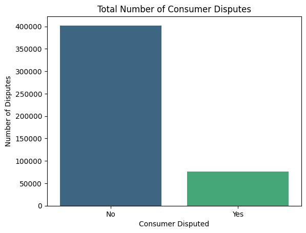

```python
# Plotting the bar graph
ax = sns.barplot(x=consumer_dispute_counts.index, y=consumer_dispute_counts.values, palette="viridis")

# Adding labels and title
ax.set(xlabel='Consumer Disputed', ylabel='Number of Disputes')
ax.set_title('Total Number of Consumer Disputes')

# Display the plot
plt.show()
```

**TASK 11:-Plot bar graph of the total no of disputes products-wise with the help of seaborn**

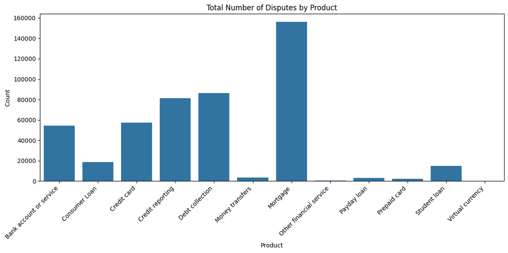

```python
# Assuming 'Product' is the column containing product names and 'Consumer disputed?' is the column indicating disputes
# Group by 'State' and count the number of disputes
consumer_product_disputed = Consumer_Complaint_df.groupby('Product')['Consumer disputed?'].count().reset_index()

plt.figure(figsize=(12, 6))
sns.barplot(data=consumer_product_disputed, x='Product', y='Consumer disputed?')
plt.title('Total Number of Disputes by Product')
plt.xlabel('Product')
plt.ylabel('Count')
plt.xticks(rotation=45, ha='right')  # Rotate x-labels for better readability
plt.tight_layout()  # Adjust layout to prevent clipping of labels
plt.show()
```

**TASK 12:-Plot bar graph of the total no of disputes with Top Issues by Highest Disputes, with the help of seaborn**

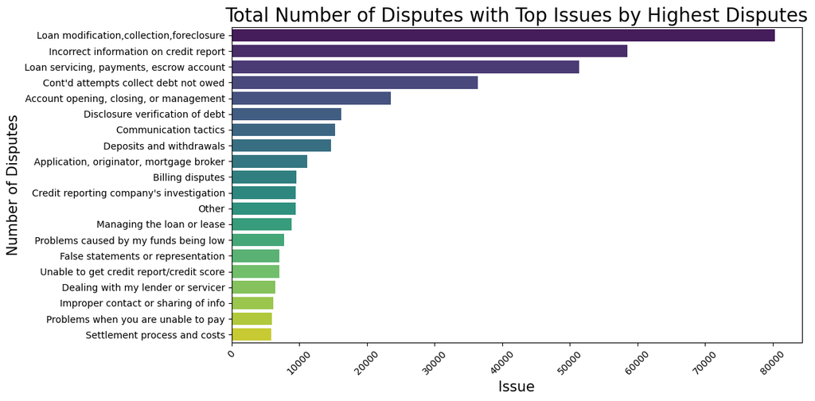

```python
consumer_issue_counts = Consumer_Complaint_df.groupby('Issue')['Consumer disputed?'].count().sort_values(ascending=False)

# Select the top 10 issues with the highest disputes
top_issues = consumer_issue_counts.head(20)

# Plotting the bar graph using Seaborn
plt.figure(figsize=(12, 6))
sns.barplot(x=top_issues.values, y=top_issues.index, palette='viridis')

plt.xlabel("Issue", fontsize=15)
plt.ylabel("Number of Disputes", fontsize=15)
plt.title("Total Number of Disputes with Top Issues by Highest Disputes", fontsize=20)
plt.xticks(rotation=45)  # Rotate x-axis labels for better readability
plt.tight_layout()  # Adjust layout to prevent clipping of labels
plt.show()
```

**TASK 13:-Plot bar graph of the total no of disputes by State with Maximum Disputes**

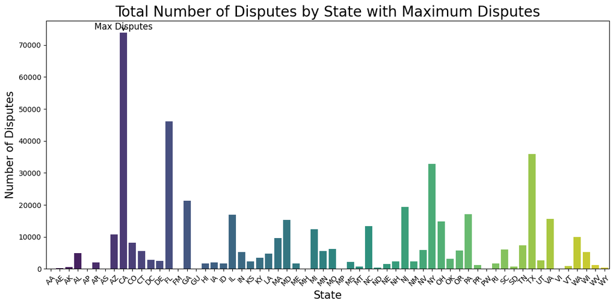

```python
# Group the data by 'State' and count the occurrences of 'Consumer disputed?'
state_dispute_counts = Consumer_Complaint_df.groupby('State')[
    'Consumer disputed?'].count().reset_index()


# Find the state with the maximum disputes
state_with_max_disputes = state_dispute_counts[state_dispute_counts[
    'Consumer disputed?'] == state_dispute_counts['Consumer disputed?'].
                                               max()]


# Plotting the bar graph using Seaborn
plt.figure(figsize=(12, 6))
sns.barplot(x='State', y='Consumer disputed?', data=state_dispute_counts,
            palette='viridis')

plt.xlabel("State", fontsize=15)
plt.ylabel("Number of Disputes", fontsize=15)
plt.title("Total Number of Disputes by State with Maximum Disputes",
          fontsize=20)
plt.xticks(rotation=45)  # Rotate x-axis labels for better readability
plt.tight_layout()  # Adjust layout to prevent clipping of labels

# Highlighting the state with maximum disputes
plt.annotate('Max Disputes',
             xy=(state_with_max_disputes.index[0], state_with_max_disputes['Consumer disputed?'].values[0]),
             xytext=(state_with_max_disputes.index[0], state_with_max_disputes['Consumer disputed?'].values[0] + 1000),
             arrowprops=dict(facecolor='black', arrowstyle='->'),
             fontsize=12, ha='center')

plt.show()
```

**TASK 14:-Plot bar graph of the total no of disputes Submitted Via different source**

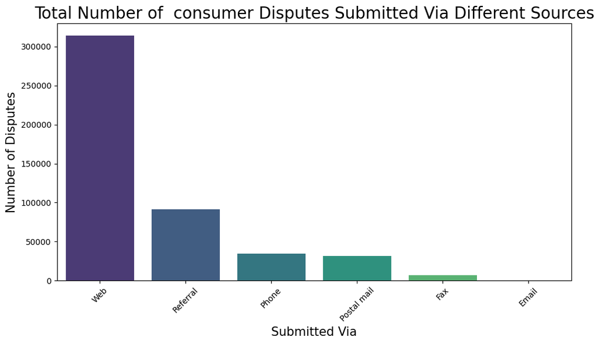

```python
# Group the data by 'Submitted Via' and count the occurrences of disputes
consumer_submitted_disputed = Consumer_Complaint_df['Submitted via'].value_counts()

# Plotting the bar graph using Seaborn
plt.figure(figsize=(10, 6))
sns.barplot(x=consumer_submitted_disputed.index, y=consumer_submitted_disputed.values, palette='viridis')

plt.xlabel("Submitted Via", fontsize=15)
plt.ylabel("Number of Disputes", fontsize=15)
plt.title("Total Number of  consumer Disputes Submitted Via Different Sources", fontsize=20)
plt.xticks(rotation=45)  # Rotate x-axis labels for better readability
plt.tight_layout()  # Adjust layout to prevent clipping of labels
plt.show()
```

**TASK 15:-Plot bar graph of the total no of disputes where the Company's Response to the Complaints**

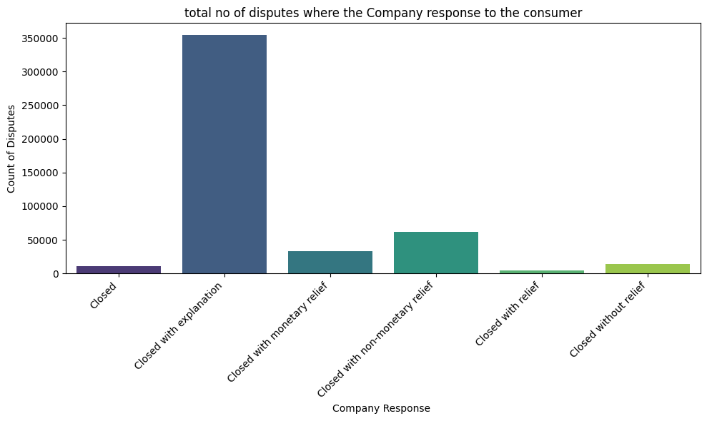

```python
consumer_complaint_response=Consumer_Complaint_df.groupby('Company response to consumer')['Consumer disputed?'].count()
# Plotting the bar graph
plt.figure(figsize=(10, 6))
sns.barplot(x=consumer_complaint_response.index,y=consumer_complaint_response.values,palette='viridis')
plt.title('total no of disputes where the Company response to the consumer')
plt.xlabel('Company Response ')
plt.ylabel('Count of Disputes')
plt.xticks(rotation=45, ha='right')  # Rotate x-labels for better readability
plt.tight_layout()  # Adjust layout to prevent clipping of labels
plt.show()
```

**TASK 16:-Plot bar graph of the total no of disputes where the Company's Response Leads to Disputes**

```python
# Group data by company's response and count the number of disputes for each response
consumer_disputes_by_response = Consumer_Complaint_df[Consumer_Complaint_df['Consumer disputed?'] == 'Yes']\
                            .groupby('Company response to consumer').size().reset_index(name='Total Disputes')
consumer_disputes_by_response
```

|  | Company response to consumer | Total Disputes |
| --- | --- | --- |
| 0 | Closed | 1928 |
| 1 | Closed with explanation | 62108 |
| 2 | Closed with monetary relief | 2864 |
| 3 | Closed with non-monetary relief | 5987 |
| 4 | Closed with relief | 426 |
| 5 | Closed without relief | 2859 |

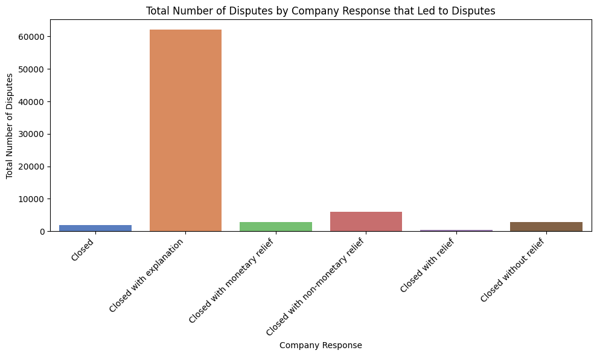

```python
# Plotting the bar graph
plt.figure(figsize=(10, 6))
sns.barplot(x='Company response to consumer', y='Total Disputes', data=consumer_disputes_by_response, palette='muted')
plt.title('Total Number of Disputes by Company Response that Led to Disputes')
plt.xlabel('Company Response')
plt.ylabel('Total Number of Disputes')
plt.xticks(rotation=45, ha='right')  # Rotate x-labels for better readability
plt.tight_layout()  # Adjust layout to prevent clipping of labels
plt.show()
```

**TASK 17:-Plot bar graph of the total no of disputes. Whether there are Disputes Instead of Timely Response**

```python
timely_response_dispute=Consumer_Complaint_df.groupby('Timely response?')['Consumer disputed?'].count().reset_index()
timely_response_dispute
```

|  | Timely response? | Consumer disputed? |
| --- | --- | --- |
| 0 | No | 8143 |
| 1 | Yes | 470273 |

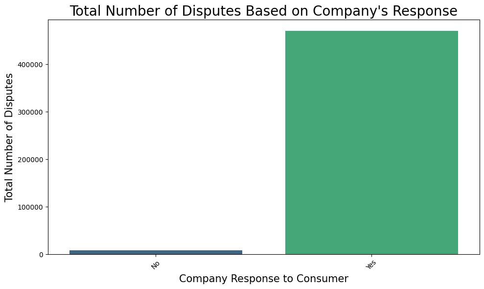

```python
# Plotting the bar graph
plt.figure(figsize=(10, 6))
sns.barplot(x='Timely response?', y='Consumer disputed?', data=timely_response_dispute, palette='viridis')

plt.xlabel("Company Response to Consumer", fontsize=15)
plt.ylabel("Total Number of Disputes", fontsize=15)
plt.title("Total Number of Disputes Based on Company's Response", fontsize=20)
plt.xticks(rotation=45)  # Rotate x-axis labels for better readability
plt.tight_layout()  # Adjust layout to prevent clipping of labels
plt.show()
```

**TASK 18:-Plot bar graph of the total no of disputes over Year Wise Complaints**

```python
year_wise_complaint=Consumer_Complaint_df.groupby('Year')['Consumer disputed?'].count().reset_index()
year_wise_complaint
```

|  | Year | Consumer disputed? |
| --- | --- | --- |
| 0 | 2011 | 1947 |
| 1 | 2012 | 56998 |
| 2 | 2013 | 85982 |
| 3 | 2014 | 119670 |
| 4 | 2015 | 133928 |
| 5 | 2016 | 79891 |

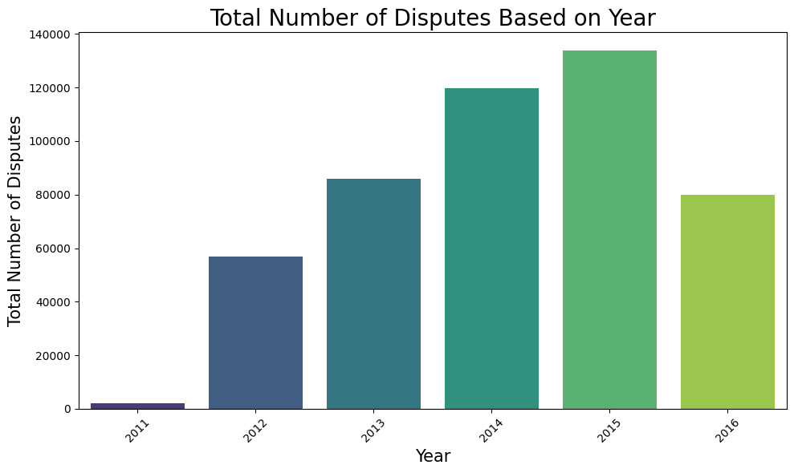

```python
# Plotting the bar graph
plt.figure(figsize=(10, 6))
sns.barplot(x='Year', y='Consumer disputed?', data=year_wise_complaint, palette='viridis')

plt.xlabel("Year", fontsize=15)
plt.ylabel("Total Number of Disputes", fontsize=15)
plt.title("Total Number of Disputes Based on Year", fontsize=20)
plt.xticks(rotation=45)  # Rotate x-axis labels for better readability
plt.tight_layout()  # Adjust layout to prevent clipping of labels
plt.show()
```

**TASK 19:-Plot bar graph of the total no of disputes over Year Wise Disputes**

```python
consumer_dispute_counts = Consumer_Complaint_df[Consumer_Complaint_df['Consumer disputed?']=='Yes']
```

```python
consumer_dispute_counts
```

|  | Product | Issue | Company | State | Submitted via | Company response to consumer | Timely response? | Consumer disputed? | Day | Month | Year | Days held | Week_Received |
| --- | --- | --- | --- | --- | --- | --- | --- | --- | --- | --- | --- | --- | --- |
| 1 | Bank account or service | Deposits and withdrawals | Wells Fargo & Company | GA | Web | Closed with explanation | Yes | Yes | 26 | 4 | 2015 | 0 | 1 |
| 4 | Debt collection | Disclosure verification of debt | HCFS Health Care Financial Services, Inc. | CA | Web | Closed with explanation | Yes | Yes | 30 | 1 | 2015 | 0 | 1 |
| 5 | Credit card | APR or interest rate | TD Bank US Holding Company | FL | Web | Closed with explanation | Yes | Yes | 10 | 1 | 2014 | 5 | 1 |
| 7 | Credit card | Payoff process | Capital One | IL | Web | Closed with explanation | Yes | Yes | 7 | 12 | 2015 | 0 | 1 |
| 8 | Bank account or service | Deposits and withdrawals | Citizens Financial Group, Inc. | PA | Web | Closed with relief | Yes | Yes | 5 | 4 | 2012 | 0 | 1 |
| ... | ... | ... | ... | ... | ... | ... | ... | ... | ... | ... | ... | ... | ... |
| 358787 | Mortgage | Credit decision / Underwriting | JPMorgan Chase & Co. | CA | Postal mail | Closed with explanation | Yes | Yes | 30 | 5 | 2014 | 5 | 1 |
| 358791 | Mortgage | Loan modification,collection,foreclosure | Bank of America | TX | Referral | Closed with explanation | Yes | Yes | 12 | 8 | 2013 | 1 | 1 |
| 358797 | Debt collection | Cont'd attempts collect debt not owed | Convergent Resources, Inc. | IN | Web | Closed with explanation | Yes | Yes | 20 | 6 | 2016 | 0 | 1 |
| 358798 | Credit reporting | Incorrect information on credit report | Equifax | IL | Web | Closed with non-monetary relief | Yes | Yes | 26 | 2 | 2013 | 0 | 1 |
| 358807 | Credit card | Payoff process | Capital One | TX | Web | Closed | Yes | Yes | 1 | 2 | 2013 | 0 | 1 |

76172 rows × 13 columns

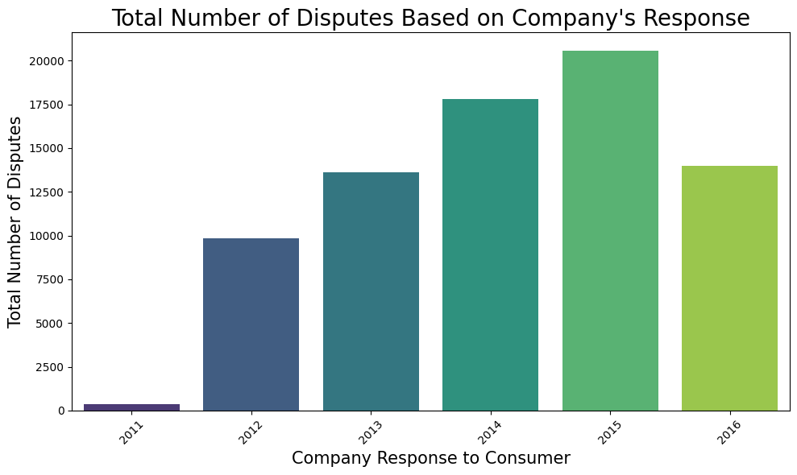

```python
# Grouping data by 'Company response to consumer' and counting the number of disputes for each group
consumer_disputes_by_response = consumer_dispute_counts.groupby('Year')['Consumer disputed?'].count().reset_index()

# Plotting the bar graph
plt.figure(figsize=(10, 6))
sns.barplot(x='Year', y='Consumer disputed?', data=consumer_disputes_by_response, palette='viridis')

plt.xlabel("Company Response to Consumer", fontsize=15)
plt.ylabel("Total Number of Disputes", fontsize=15)
plt.title("Total Number of Disputes Based on Company's Response", fontsize=20)
plt.xticks(rotation=45)  # Rotate x-axis labels for better readability
plt.tight_layout()  # Adjust layout to prevent clipping of labels
plt.show()
```

**TASK 20:-Plot bar graph of Top Companies with Highest Complaints**

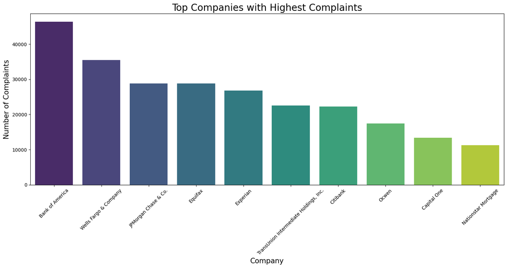

```python
# Group the data by 'Issue' and count the occurrences of 'Consumer disputed?'
issue_counts = Consumer_Complaint_df.groupby('Company')['Consumer disputed?'].count().reset_index()

# Sort the issues based on the number of disputes in descending order to get the top issues
top_issues = issue_counts.sort_values(by='Consumer disputed?', ascending=False).head(10)

# Plotting the bar graph using Seaborn
plt.figure(figsize=(15, 8))
sns.barplot(x='Company', y='Consumer disputed?', data=top_issues, palette='viridis')

plt.xlabel("Company", fontsize=15)
plt.ylabel("Number of Complaints", fontsize=15)
plt.title("Top Companies with Highest Complaints", fontsize=20)

plt.xticks(rotation=45)  # Rotate x-axis labels for better readability
plt.tight_layout()  # Adjust layout to prevent clipping of labels
plt.show()
```

**TASK 21:-Converte all negative days held to zero (it is the time taken by the authority that can't be negative)**

```python
print(len(Consumer_Complaint_df['Days held'].unique()))
Consumer_Complaint_df['Days held'].unique()
```

```
398
```

```
array([  0,   3,   1,   6,   7,   4,   2,   5,  11,  19,  58,  32,  33,
        12,   8,  20,  -1,  18,  13,  34,  17,  72,  10,  14,   9,  15,
       414,  23, 211,  31,  22,  25,  30,  27,  21,  43,  24, 199,  16,
        29,  26,  36, 212,  35,  89, 281,  39,  52,  57,  37,  56,  42,
        46, 125,  28,  55, 127, 184, 191, 203, 126,  44,  40,  47,  48,
        50,  45,  59,  41, 231,  64,  62,  49,  96, 158,  38,  79, 228,
       103,  51, 101, 179, 159, 160,  83,  78, 190, 166,  95,  76, 324,
       185,  84,  86, 139,  60,  99, 239,  69,  91, 230,  65,  80,  61,
        73,  54,  75, 202, 352,  71, 197, 208, 162,  63, 154, 195, 196,
       100, 167, 171, 238, 254, 113,  77, 106, 165, 118, 141,  82, 290,
        94, 163, 220,  92, 157,  70, 265, 262, 155, 318, 136, 213,  53,
       181, 214, 150, 271, 222, 237,  67, 224, 266, 330, 142, 198, 178,
       201, 395, 105, 246, 173, 217,  66, 117, 122, 140, 305, 137, 109,
       207, 252, 250, 192, 134, 296, 152, 229, 111, 194, 112,  87, 148,
       204,  97, 209, 189,  74, 138, 175, 382, 575, 301, 232, 119, 253,
```

[output cut: 16 more lines]

```python
# Assuming 'Days held' is the column in the DataFrame where you want to convert negative values to zero
Consumer_Complaint_df.loc[Consumer_Complaint_df['Days held'] < 0, 'Days held'] = 0
```

```python
print(len(Consumer_Complaint_df['Days held'].unique()))
Consumer_Complaint_df['Days held'].unique()
```

```
397
```

```
array([  0,   3,   1,   6,   7,   4,   2,   5,  11,  19,  58,  32,  33,
        12,   8,  20,  18,  13,  34,  17,  72,  10,  14,   9,  15, 414,
        23, 211,  31,  22,  25,  30,  27,  21,  43,  24, 199,  16,  29,
        26,  36, 212,  35,  89, 281,  39,  52,  57,  37,  56,  42,  46,
       125,  28,  55, 127, 184, 191, 203, 126,  44,  40,  47,  48,  50,
        45,  59,  41, 231,  64,  62,  49,  96, 158,  38,  79, 228, 103,
        51, 101, 179, 159, 160,  83,  78, 190, 166,  95,  76, 324, 185,
        84,  86, 139,  60,  99, 239,  69,  91, 230,  65,  80,  61,  73,
        54,  75, 202, 352,  71, 197, 208, 162,  63, 154, 195, 196, 100,
       167, 171, 238, 254, 113,  77, 106, 165, 118, 141,  82, 290,  94,
       163, 220,  92, 157,  70, 265, 262, 155, 318, 136, 213,  53, 181,
       214, 150, 271, 222, 237,  67, 224, 266, 330, 142, 198, 178, 201,
       395, 105, 246, 173, 217,  66, 117, 122, 140, 305, 137, 109, 207,
       252, 250, 192, 134, 296, 152, 229, 111, 194, 112,  87, 148, 204,
        97, 209, 189,  74, 138, 175, 382, 575, 301, 232, 119, 253, 116,
```

[output cut: 16 more lines]

**TASK 22:-Drop Unnecessary Columns for the Model Building like:'Company', 'State', 'Year_Received', 'Days_held'**

```python
unnecessary_columns_to_drop=['Company','State','Week_Received','Days held']
Consumer_Complaint_df=Consumer_Complaint_df.drop(columns=unnecessary_columns_to_drop)
```

```python
Consumer_Complaint_df
```

|  | Product | Issue | Submitted via | Company response to consumer | Timely response? | Consumer disputed? | Day | Month | Year |
| --- | --- | --- | --- | --- | --- | --- | --- | --- | --- |
| 0 | Credit card | Customer service / Customer relations | Web | Closed with monetary relief | Yes | No | 17 | 1 | 2015 |
| 1 | Consumer Loan | Payment to acct not credited | Phone | Closed with explanation | Yes | No | 22 | 6 | 2016 |
| 2 | Credit card | Credit line increase/decrease | Web | Closed with explanation | Yes | No | 4 | 9 | 2015 |
| 3 | Consumer Loan | Problems when you are unable to pay | Web | Closed with non-monetary relief | Yes | No | 17 | 5 | 2016 |
| 4 | Debt collection | Improper contact or sharing of info | Web | Closed with explanation | Yes | No | 7 | 7 | 2016 |
| ... | ... | ... | ... | ... | ... | ... | ... | ... | ... |
| 358805 | Credit reporting | Incorrect information on credit report | Web | Closed with non-monetary relief | Yes | No | 14 | 4 | 2014 |
| 358806 | Mortgage | Loan modification,collection,foreclosure | Referral | Closed with non-monetary relief | Yes | No | 14 | 3 | 2013 |
| 358807 | Credit card | Payoff process | Web | Closed | Yes | Yes | 1 | 2 | 2013 |
| 358808 | Debt collection | Cont'd attempts collect debt not owed | Phone | Closed with non-monetary relief | Yes | No | 25 | 6 | 2015 |
| 358809 | Credit reporting | Incorrect information on credit report | Referral | Closed with explanation | Yes | No | 12 | 5 | 2015 |

478416 rows × 9 columns

**TASK 23:-Change Consumer Disputed Column to 0 and 1(yes to 1, and no to 0)**

```python
Consumer_Complaint_df["Consumer disputed?"] = Consumer_Complaint_df[
    "Consumer disputed?"].replace({"Yes": 1, "No": 0})
```

```python
Consumer_Complaint_df
```

|  | Product | Issue | Submitted via | Company response to consumer | Timely response? | Consumer disputed? | Day | Month | Year |
| --- | --- | --- | --- | --- | --- | --- | --- | --- | --- |
| 0 | Credit card | Customer service / Customer relations | Web | Closed with monetary relief | Yes | 0 | 17 | 1 | 2015 |
| 1 | Consumer Loan | Payment to acct not credited | Phone | Closed with explanation | Yes | 0 | 22 | 6 | 2016 |
| 2 | Credit card | Credit line increase/decrease | Web | Closed with explanation | Yes | 0 | 4 | 9 | 2015 |
| 3 | Consumer Loan | Problems when you are unable to pay | Web | Closed with non-monetary relief | Yes | 0 | 17 | 5 | 2016 |
| 4 | Debt collection | Improper contact or sharing of info | Web | Closed with explanation | Yes | 0 | 7 | 7 | 2016 |
| ... | ... | ... | ... | ... | ... | ... | ... | ... | ... |
| 358805 | Credit reporting | Incorrect information on credit report | Web | Closed with non-monetary relief | Yes | 0 | 14 | 4 | 2014 |
| 358806 | Mortgage | Loan modification,collection,foreclosure | Referral | Closed with non-monetary relief | Yes | 0 | 14 | 3 | 2013 |
| 358807 | Credit card | Payoff process | Web | Closed | Yes | 1 | 1 | 2 | 2013 |
| 358808 | Debt collection | Cont'd attempts collect debt not owed | Phone | Closed with non-monetary relief | Yes | 0 | 25 | 6 | 2015 |
| 358809 | Credit reporting | Incorrect information on credit report | Referral | Closed with explanation | Yes | 0 | 12 | 5 | 2015 |

478416 rows × 9 columns

**TASK 24:-Create Dummy Variables for categorical features and concat with the original data frame like: 'Product,’ 'Submitted via,’ 'Company response to consumer,’ 'Timely response?'**

```python
# Specify the categorical features for which you want to create dummy variables
consumer_categorical_features = ['Product', 'Submitted via',
                        'Company response to consumer', 'Timely response?']

# Create dummy variables for the categorical features
dummy_variables_test = pd.get_dummies(Consumer_Complaint_df[consumer_categorical_features])

# Concatenate the original DataFrame with the dummy variables
Consumer_Complaint_df = pd.concat([Consumer_Complaint_df,dummy_variables_test],axis=1)

# Drop the original categorical features from the DataFrame
Consumer_Complaint_df.drop(columns=consumer_categorical_features, inplace=True)
```

```python
Consumer_Complaint_df
```

|  | Issue | Consumer disputed? | Day | Month | Year | Product_Bank account or service | Product_Consumer Loan | Product_Credit card | Product_Credit reporting | Product_Debt collection | ... | Submitted via_Referral | Submitted via_Web | Company response to consumer_Closed | Company response to consumer_Closed with explanation | Company response to consumer_Closed with monetary relief | Company response to consumer_Closed with non-monetary relief | Company response to consumer_Closed with relief | Company response to consumer_Closed without relief | Timely response?_No | Timely response?_Yes |
| --- | --- | --- | --- | --- | --- | --- | --- | --- | --- | --- | --- | --- | --- | --- | --- | --- | --- | --- | --- | --- | --- |
| 0 | Customer service / Customer relations | 0 | 17 | 1 | 2015 | 0 | 0 | 1 | 0 | 0 | ... | 0 | 1 | 0 | 0 | 1 | 0 | 0 | 0 | 0 | 1 |
| 1 | Payment to acct not credited | 0 | 22 | 6 | 2016 | 0 | 1 | 0 | 0 | 0 | ... | 0 | 0 | 0 | 1 | 0 | 0 | 0 | 0 | 0 | 1 |
| 2 | Credit line increase/decrease | 0 | 4 | 9 | 2015 | 0 | 0 | 1 | 0 | 0 | ... | 0 | 1 | 0 | 1 | 0 | 0 | 0 | 0 | 0 | 1 |
| 3 | Problems when you are unable to pay | 0 | 17 | 5 | 2016 | 0 | 1 | 0 | 0 | 0 | ... | 0 | 1 | 0 | 0 | 0 | 1 | 0 | 0 | 0 | 1 |
| 4 | Improper contact or sharing of info | 0 | 7 | 7 | 2016 | 0 | 0 | 0 | 0 | 1 | ... | 0 | 1 | 0 | 1 | 0 | 0 | 0 | 0 | 0 | 1 |
| ... | ... | ... | ... | ... | ... | ... | ... | ... | ... | ... | ... | ... | ... | ... | ... | ... | ... | ... | ... | ... | ... |
| 358805 | Incorrect information on credit report | 0 | 14 | 4 | 2014 | 0 | 0 | 0 | 1 | 0 | ... | 0 | 1 | 0 | 0 | 0 | 1 | 0 | 0 | 0 | 1 |
| 358806 | Loan modification,collection,foreclosure | 0 | 14 | 3 | 2013 | 0 | 0 | 0 | 0 | 0 | ... | 1 | 0 | 0 | 0 | 0 | 1 | 0 | 0 | 0 | 1 |
| 358807 | Payoff process | 1 | 1 | 2 | 2013 | 0 | 0 | 1 | 0 | 0 | ... | 0 | 1 | 1 | 0 | 0 | 0 | 0 | 0 | 0 | 1 |
| 358808 | Cont'd attempts collect debt not owed | 0 | 25 | 6 | 2015 | 0 | 0 | 0 | 0 | 1 | ... | 0 | 0 | 0 | 0 | 0 | 1 | 0 | 0 | 0 | 1 |
| 358809 | Incorrect information on credit report | 0 | 12 | 5 | 2015 | 0 | 0 | 0 | 1 | 0 | ... | 1 | 0 | 0 | 1 | 0 | 0 | 0 | 0 | 0 | 1 |

478416 rows × 31 columns

**TASK 25:-Scaling the Data Sets (note: discard dependent variable before doing standardization) and Make feature Selection with the help of PCA up to 80% of the information.**

```python
from sklearn.preprocessing import StandardScaler,LabelEncoder
from sklearn.decomposition import PCA
```

```python
# Separate the dependent variable(target) from the independent variable(features)
X = Consumer_Complaint_df.drop(columns=['Consumer disputed?'])  # Independent variables
y = Consumer_Complaint_df['Consumer disputed?']  # Dependent variable

# Label encode the 'Issue' column
label_encoder = LabelEncoder()
X['Issue'] = label_encoder.fit_transform(X['Issue'])

# Standardize the independent variables
scaler = StandardScaler()
X_scaled = scaler.fit_transform(X)

# Perform PCA to reduce dimensionality while retaining 17 principal components
pca = PCA(n_components=17)
consumer_complaint_pca = pca.fit_transform(X_scaled)

# Print the number of principal components selected
print('Number of principal components selected:', pca.n_components_)

# Optionally, you can convert the PCA results back to DataFrame
consumer_complaint_pca_df = pd.DataFrame(consumer_complaint_pca, columns=[f"pc{i}" for i in range(1, pca.n_components_ + 1)])

# Concatenate the dependent variable (target) with the principal components
consumer_complaint_pca_df = pd.DataFrame(consumer_complaint_pca, columns=[f"pc{i}" for i in range(1, pca.n_components_ + 1)])
consumer_complaint_pca_df['Consumer disputed?'] = y.reset_index(drop=True)

# Now, X_pca_df contains the principal components along with the dependent variable.
consumer_complaint_pca_df
```

```
Number of principal components selected: 17
```

|  | pc1 | pc2 | pc3 | pc4 | pc5 | pc6 | pc7 | pc8 | pc9 | pc10 | pc11 | pc12 | pc13 | pc14 | pc15 | pc16 | pc17 | Consumer disputed? |
| --- | --- | --- | --- | --- | --- | --- | --- | --- | --- | --- | --- | --- | --- | --- | --- | --- | --- | --- |
| 0 | 0.298576 | 0.016297 | 3.164878 | -0.914229 | -1.705521 | 2.097000 | 0.431456 | -0.820568 | 1.464607 | -2.047689 | -0.566005 | 0.203477 | -0.371553 | 0.275568 | -0.046153 | -0.277214 | 0.156497 | 0 |
| 1 | -0.239313 | -0.326541 | -1.290896 | -0.498536 | 1.248096 | 2.781953 | -2.668176 | 3.124714 | 1.711138 | 0.761144 | 2.674074 | -0.023000 | -0.224675 | 0.572665 | 1.448074 | 0.584155 | -0.445088 | 0 |
| 2 | 0.811096 | -0.373359 | 0.400981 | -1.156006 | -1.157076 | 0.659692 | 1.713887 | 0.438289 | -0.081244 | -0.845691 | 0.161576 | 0.210998 | 0.174644 | -0.064320 | -0.791277 | -0.730472 | 0.283647 | 0 |
| 3 | 1.403542 | -0.821610 | 1.176734 | 2.487485 | 0.153747 | 1.891814 | -2.673015 | 0.805439 | 0.819348 | 0.268698 | 3.157523 | 0.012539 | 0.093764 | 0.691800 | 0.947777 | 0.252269 | -0.283772 | 0 |
| 4 | 1.973751 | -0.308468 | -0.608182 | -1.009096 | -0.093171 | -0.891122 | -0.486712 | 0.166003 | 0.056787 | -0.424317 | 0.399229 | -0.054410 | -0.074269 | 0.099021 | -0.639543 | -0.793451 | 0.320533 | 0 |
| ... | ... | ... | ... | ... | ... | ... | ... | ... | ... | ... | ... | ... | ... | ... | ... | ... | ... | ... |
| 478411 | 1.295436 | -0.921728 | 2.155091 | 2.536347 | 1.054080 | -0.324908 | 0.003285 | -0.459777 | 0.201236 | 0.698298 | -0.133721 | -0.433867 | 0.656256 | -0.278393 | 0.013450 | 0.032664 | -0.031518 | 0 |
| 478412 | -2.311059 | 0.322577 | 1.032900 | 2.215870 | 0.737899 | -1.297847 | -0.965482 | -0.844084 | 0.413225 | -0.267871 | 0.081854 | -0.994514 | 0.380013 | -0.151362 | 0.019502 | 0.153644 | -0.145114 | 0 |
| 478413 | -0.019657 | 0.755956 | 2.097864 | 0.942221 | -1.642740 | -0.558191 | -1.209330 | 0.557291 | 0.604679 | -2.083860 | 0.794576 | 3.983222 | -0.677405 | -0.520947 | -1.918945 | -0.224908 | 0.425215 | 1 |
| 478414 | 0.466275 | 0.498953 | 2.235062 | -0.648198 | 2.125757 | -1.941487 | -1.769568 | 2.668390 | 1.020702 | 0.290792 | -0.300423 | -1.532584 | 0.128357 | 0.175568 | 1.066357 | 0.693998 | -0.399686 | 0 |
| 478415 | -0.726548 | -0.522791 | -0.636248 | 0.309673 | 1.978506 | 0.283343 | 0.481927 | -1.462640 | 0.375755 | 0.157007 | 0.441875 | -0.455797 | 0.195800 | -0.301794 | -0.290015 | -0.168533 | 0.034039 | 0 |

478416 rows × 18 columns

**TASK 26:-Splitting the Data Sets Into X and Y by the dependent and independent variables (data selected by PCA)**

```python
#Step-1:- Separate the target variable and the feature vectors:
X = consumer_complaint_pca_df.drop(['Consumer disputed?'], axis=1)
y = consumer_complaint_pca_df['Consumer disputed?']

#Step-2:- To check the shape of X & y:
print("The shape of our X is:- ",X.shape)
print("The shape of our y is:- ",y.shape)

#Step-3:- Checking the X data:
X
```

```
The shape of our X is:-  (478416, 17)
The shape of our y is:-  (478416,)
```

|  | pc1 | pc2 | pc3 | pc4 | pc5 | pc6 | pc7 | pc8 | pc9 | pc10 | pc11 | pc12 | pc13 | pc14 | pc15 | pc16 | pc17 |
| --- | --- | --- | --- | --- | --- | --- | --- | --- | --- | --- | --- | --- | --- | --- | --- | --- | --- |
| 0 | 0.298576 | 0.016297 | 3.164878 | -0.914229 | -1.705521 | 2.097000 | 0.431456 | -0.820568 | 1.464607 | -2.047689 | -0.566005 | 0.203477 | -0.371553 | 0.275568 | -0.046153 | -0.277214 | 0.156497 |
| 1 | -0.239313 | -0.326541 | -1.290896 | -0.498536 | 1.248096 | 2.781953 | -2.668176 | 3.124714 | 1.711138 | 0.761144 | 2.674074 | -0.023000 | -0.224675 | 0.572665 | 1.448074 | 0.584155 | -0.445088 |
| 2 | 0.811096 | -0.373359 | 0.400981 | -1.156006 | -1.157076 | 0.659692 | 1.713887 | 0.438289 | -0.081244 | -0.845691 | 0.161576 | 0.210998 | 0.174644 | -0.064320 | -0.791277 | -0.730472 | 0.283647 |
| 3 | 1.403542 | -0.821610 | 1.176734 | 2.487485 | 0.153747 | 1.891814 | -2.673015 | 0.805439 | 0.819348 | 0.268698 | 3.157523 | 0.012539 | 0.093764 | 0.691800 | 0.947777 | 0.252269 | -0.283772 |
| 4 | 1.973751 | -0.308468 | -0.608182 | -1.009096 | -0.093171 | -0.891122 | -0.486712 | 0.166003 | 0.056787 | -0.424317 | 0.399229 | -0.054410 | -0.074269 | 0.099021 | -0.639543 | -0.793451 | 0.320533 |
| ... | ... | ... | ... | ... | ... | ... | ... | ... | ... | ... | ... | ... | ... | ... | ... | ... | ... |
| 478411 | 1.295436 | -0.921728 | 2.155091 | 2.536347 | 1.054080 | -0.324908 | 0.003285 | -0.459777 | 0.201236 | 0.698298 | -0.133721 | -0.433867 | 0.656256 | -0.278393 | 0.013450 | 0.032664 | -0.031518 |
| 478412 | -2.311059 | 0.322577 | 1.032900 | 2.215870 | 0.737899 | -1.297847 | -0.965482 | -0.844084 | 0.413225 | -0.267871 | 0.081854 | -0.994514 | 0.380013 | -0.151362 | 0.019502 | 0.153644 | -0.145114 |
| 478413 | -0.019657 | 0.755956 | 2.097864 | 0.942221 | -1.642740 | -0.558191 | -1.209330 | 0.557291 | 0.604679 | -2.083860 | 0.794576 | 3.983222 | -0.677405 | -0.520947 | -1.918945 | -0.224908 | 0.425215 |
| 478414 | 0.466275 | 0.498953 | 2.235062 | -0.648198 | 2.125757 | -1.941487 | -1.769568 | 2.668390 | 1.020702 | 0.290792 | -0.300423 | -1.532584 | 0.128357 | 0.175568 | 1.066357 | 0.693998 | -0.399686 |
| 478415 | -0.726548 | -0.522791 | -0.636248 | 0.309673 | 1.978506 | 0.283343 | 0.481927 | -1.462640 | 0.375755 | 0.157007 | 0.441875 | -0.455797 | 0.195800 | -0.301794 | -0.290015 | -0.168533 | 0.034039 |

478416 rows × 17 columns

```python
#Step-4:- Checking the y data:

y.head()
```

```
0    0
1    0
2    0
3    0
4    0
Name: Consumer disputed?, dtype: int64
```

**TASK 27:-Build given models and measure their test and validation accuracy: o LogisticRegression**

o DecisionTreeClassifier o RandomForestClassifier o AdaBoostClassifier o GradientBoostingClassifier o KNeighborsClassifier o XGBClassifier

```python
from sklearn.model_selection import train_test_split
from sklearn.linear_model import LogisticRegression
from sklearn.tree import DecisionTreeClassifier
from sklearn.ensemble import RandomForestClassifier, AdaBoostClassifier, GradientBoostingClassifier
from sklearn.neighbors import KNeighborsClassifier
from xgboost import XGBClassifier
from sklearn.metrics import accuracy_score
```

```python
#Step-1:- Split our dataset into train and test datasets:
X_train, X_test, y_train, y_test = train_test_split(X,y,
                            test_size=0.2, random_state= 7)


#Step-2:- To check the shape of "X_train", "X_test" & "y_train", "y_test":
print("The shape of X_train is:- ", X_train.shape)
print("The shape of X_test is:- ", X_test.shape)
print("The shape of y_train is:- ", y_train.shape)
print("The shape of y_test is:- ", y_test.shape)
```

```
The shape of X_train is:-  (382732, 17)
The shape of X_test is:-  (95684, 17)
The shape of y_train is:-  (382732,)
The shape of y_test is:-  (95684,)
```

```python
#STEP 1 Initialize models
models = {
    "Logistic Regression": LogisticRegression(),
    "Decision Tree": DecisionTreeClassifier(),
    "Random Forest": RandomForestClassifier(),
    "AdaBoost": AdaBoostClassifier(),
    "Gradient Boosting": GradientBoostingClassifier(),
    "K-Nearest Neighbors": KNeighborsClassifier(),
    "XGBoost": XGBClassifier()
}

#STEP 2 Train and evaluate models
accuracies = {}
for name, model in models.items():
    model.fit(X_train, y_train)
    train_acc = accuracy_score(y_train, model.predict(X_train))
    test_acc = accuracy_score(y_test, model.predict(X_test))
    accuracies[name] = test_acc
    print(f"{name}:")
    print(f" - Training Accuracy: {train_acc:.4f}")
    print(f" - Testing Accuracy: {test_acc:.4f}")
```

```
Logistic Regression:
 - Training Accuracy: 0.8407
 - Testing Accuracy: 0.8411
Decision Tree:
 - Training Accuracy: 0.8868
 - Testing Accuracy: 0.8040
Random Forest:
 - Training Accuracy: 0.8868
 - Testing Accuracy: 0.8174
AdaBoost:
 - Training Accuracy: 0.8407
 - Testing Accuracy: 0.8412
Gradient Boosting:
 - Training Accuracy: 0.8409
 - Testing Accuracy: 0.8414
K-Nearest Neighbors:
 - Training Accuracy: 0.8452
 - Testing Accuracy: 0.8223
XGBoost:
 - Training Accuracy: 0.8432
 - Testing Accuracy: 0.8427
```

**TASK 28:-Whoever gives the most accurate result uses it and predicts the outcome for the test file and fills its dispute column so the business team can take some action accordingly.**

```python
#Step-1:- Selecting the best model with the highest accuracy:
consumer_best_model_name = max(accuracies, key=accuracies.get)
consumer_best_model = models[consumer_best_model_name]

#Step-2:- Printing out the best model:
print('The best model is:- ', consumer_best_model_name)

#Step-3:- Predict the outcome for the test file:
consumer_test_predictions = consumer_best_model.predict(X_test)

#Step-4:- Fill the 'Consumer disputed?' column with the predicted outcomes:
consumer_predicted_df = X_test.copy()
consumer_predicted_df['Consumer disputed?'] = consumer_test_predictions

# Step-5:- Viewing the starting few records of predicted_df:
consumer_predicted_df.head()
```

```
The best model is:-  XGBoost
```

|  | pc1 | pc2 | pc3 | pc4 | pc5 | pc6 | pc7 | pc8 | pc9 | pc10 | pc11 | pc12 | pc13 | pc14 | pc15 | pc16 | pc17 | Consumer disputed? |
| --- | --- | --- | --- | --- | --- | --- | --- | --- | --- | --- | --- | --- | --- | --- | --- | --- | --- | --- |
| 367441 | 1.337348 | -0.855960 | -1.207282 | 0.438400 | -0.427569 | 2.446685 | -1.872414 | 0.256753 | 1.852043 | 0.168788 | 3.219346 | 0.766537 | -0.200711 | 0.639609 | 0.540741 | -0.256228 | -0.029262 | 0 |
| 345399 | -0.913249 | 0.484818 | 0.485470 | -3.485761 | 1.871910 | 0.273186 | -0.680223 | 1.440425 | -0.267793 | 2.043252 | -0.533594 | 0.226517 | 0.656443 | -0.405867 | -0.413172 | -0.628330 | 0.231446 | 0 |
| 442699 | -1.909735 | 0.067531 | -1.625414 | 0.200480 | 0.476555 | -0.291973 | -0.439256 | -1.231131 | 0.718552 | -0.505410 | 0.116197 | -0.067750 | 0.195635 | -0.261292 | -0.943986 | -0.792549 | 0.283206 | 0 |
| 462152 | 1.233931 | -0.915788 | -0.164757 | 0.319670 | 0.468513 | 0.177244 | 0.936635 | -0.757672 | 0.497150 | 0.608555 | -0.096003 | 0.182712 | 0.330986 | -0.335187 | -0.230393 | -0.287429 | 0.143068 | 0 |
| 245511 | -0.193571 | -0.885260 | -0.498853 | 0.865290 | 3.123962 | 0.723427 | 2.389779 | 0.737873 | -0.469292 | -0.034788 | -0.063584 | 1.408456 | -1.260058 | -0.262072 | -0.785734 | -0.738248 | 0.344926 | 0 |

# END OF PROJECT 2

# SUBMITTED BY:-SUBHASHREE SATAPATHY